# Analysis of the citizen initiatives and civic crowdfunding survey for BrusselsTogether

R code for reproducible research

Paramio J., Piette C., Heremans S., Comté F., Mercier A.

23 mai, 2018

[figure not shown]

# Summary

This document provides the R code used to analyze survey data in the context of a the market research done by students at ULB/Sovay Brussels School on citizen initiatives and, in particular, civic crowdfunding. This research originated from a need by BrusselsTogether to better understand the factors driving the success of their own civic crowdfunding platform.

The present document provides all of the code written in R in order for anyone to be able to check and reproduce the findings resulting from the online survey launched in April 2018 by the students.

The input files as well as the code can be retrieved on our [Github page](https://github.com/antoinemercier82/BrusselsTogether-Mkg-Analytics-Solvay-BS-2018).

# Data Preprocessing

### Preparation

```r
library(readr)
library(lubridate)
library(stringr)
library(dplyr)
library(tidyr)
library(ggplot2)
library(hrbrthemes)
library(knitr)
library(kableExtra)
library(lavaan)
library(likert)
library(reshape2)
library(RColorBrewer)
library(ggthemes)
library(tibble)
library(broom)
library(rebus)
```

### Import

There are only two input files (`Citizen initiative.csv` and `header_lookup.txt`) which can be retrieved from the Github page mentionned above.

```r
survey_df <- read_csv("inputs/Citizen initiative.csv")
header_lookup <- read_delim("inputs/header_lookup.txt", delim = ";")
# names(survey_df) <- header_lookup$df_header
```

### Preprocessing

The preprocessing code is available below, although in order to improve the clarity of this document, **it is better to hide this code** (click on the `Hide` button on the right).

```r
# Dates preprocessing
survey_df$date <- str_replace(string = survey_df$date,
                              pattern = "M GMT.*$",
                              replacement = "M")

survey_df$date <- str_replace_all(string = survey_df$date,
                                  pattern = "/",
                                  replacement = "-")

survey_df$date <- ymd_hms(survey_df$date)

survey_df <- survey_df %>%
                filter(date > "2018-04-27 20:00:00")

# Language preprocessing
lut_lang <- c("English" = "English",
              "Nederlands" = "Dutch",
              "Français" = "French")

survey_df$lang <- lut_lang[survey_df$lang]

# Grouping preprocessing
lut_group_eng <- c("Citizen with no active implication in a local citizen's initiative, social project or social organization." = "Citizen_not_active",
                   "Active member of a local citizen's initiative, social project or social organization." = "Active_member",
                   "Citizen with casual volonteering for a local citizen's initiative, social project or social organization." = "Citizen_casual_vol")

lut_group_nl <- c("Een burger die geen deel uitmaakt van een lokaal burgerinitiatief, een sociaal project of een sociale organisatie." = "Citizen_not_active",
                  "Een burger die occasioneel bijdraagt als vrijliger van een lokaal burgerinitiatief, een sociaal project of een sociale organisatie." = "Citizen_casual_vol",
                  "Een actief lid van een lokaal burgerinitiatief, van een sociaal project of een sociale organisatie." = "Active_member")

lut_group_fr <- c("Citoyen.ne sans appartenance à une initiative citoyenne locale, un projet social ou une organisation sociale." = "Citizen_not_active",
                  "Citoyen.ne contribuant de manière occasionnelle en tant que volontaire à une initiative citoyenne locale, un projet social ou une organisation sociale." = "Citizen_casual_vol",
                  "Membre actif d'une initiative citoyenne locale, d'un projet social ou d'une organisation sociale." = "Active_member")


survey_df$grouping_eng <- lut_group_eng[survey_df$grouping_eng]
survey_df$grouping_nl <- lut_group_nl[survey_df$grouping_nl]
survey_df$grouping_fr <- lut_group_fr[survey_df$grouping_fr]

# Entrepreuneurs interest preprocessing
lut_e_int_eng <- c("I am not interested in joining a civic crowdfunding platform." = "Not_interested",
                   "I could be interested to join a civic crowdfunding platform." = "Could_be_interested",
                   "I am ready to join a civic crowdfunding platform." = "Is_ready")

survey_df$e_interest_nl <- str_replace(survey_df$e_interest_nl,
                                       pattern = "een " %R% ANY_CHAR %R% "civic crowdfunding" %R% ANY_CHAR %R% " platform",
                                       replacement = "een civic crowdfunding platform")

lut_e_int_nl <- c("Ik ben niet geinteresseerd bij het toetreden van een civic crowdfunding platform." = "Not_interested",
                  "Ik zou geinteresseerd kunnen zijn in het toetreden van een civic crowdfunding platform." = "Could_be_interested",
                  "Ik wil deel uitmaken van een civic crowdfunding platform." = "Is_ready")

lut_e_int_fr <- c("Je ne suis pas intéressé.e par l'adhésion à une plateforme de crowdfunding citoyen." = "Not_interested",
                  "Je pourrais être intéressé.e par l'adhésion à une plateforme de crowdfunding citoyen." = "Could_be_interested",
                  "Je suis prêt.e à rejoindre une plateforme de crowdfunding citoyen." = "Is_ready")

survey_df$e_interest_eng <- lut_e_int_eng[survey_df$e_interest_eng]
survey_df$e_interest_nl <- lut_e_int_nl[survey_df$e_interest_nl]
survey_df$e_interest_fr <- lut_e_int_fr[survey_df$e_interest_fr]

# Likert scale questions preprocessing
lut_likert_nl <- c("Helemaal niet akkoord" = "Strongly disagree",
                   "Niet akkoord" = "Disagree",
                   "Geen mening" = "Neither agree nor disagree",
                   "Akkoord" = "Agree",
                   "Helemaal akkoord" = "Strongly agree",
                   "Helemaal niet akkoord" = "Strongly disagree",
                   "niet akkoord" = "Disagree",
                   "geen mening" = "Neither agree nor disagree",
                   "akkoord" = "Agree",
                   "helemaal akkoord" = "Strongly agree")

lut_likert_fr <- c("Pas du tout d'accord" = "Strongly disagree",
                   "Pas d'accord" = "Disagree",
                   "Sans opinion" = "Neither agree nor disagree",
                   "D'accord" = "Agree",
                   "Tout à fait d'accord" = "Strongly agree")

survey_df[] <- lapply(colnames(survey_df),
                      function(x) {
                        y <- survey_df[[x]]
                        if (str_detect(x, pattern = "^._.[0-9]_nl$")) {
                          y <- lut_likert_nl[y]
                          }
                        return(y)
                        })

survey_df[] <- lapply(colnames(survey_df),
                      function(x) {
                        y <- survey_df[[x]]
                        if (str_detect(x, pattern = "^._.[0-9]_fr$")) {
                          y <- lut_likert_fr[y]
                        }
                        return(y)
                      })

# Citizen interest preprocessing
lut_c_int_eng <- c("I am not interested in citizen's initiatives." = "Not_interested",
                   "I could be interested to fund a citizen's initiative." = "Could_be_interested_Fund",
                   "I could be interested to volunteer for a citizen's initiative." = "Could_be_interested_Vol",
                   "I am ready to fund a citizen's initiative." = "Is_ready_Fund",
                   "I am ready to volunteer for a citizen's initiative." = "Is_ready_Vol")

lut_c_int_nl <- c("Ik ben niet geinteresseerd door burgerinitiatieven" = "Not_interested",
                  "Ik zou eventueel geinteresseerd kunnen zijn door het financieren van burgerinitiatieven" = "Could_be_interested_Fund",
                  "Ik zou eventueel geinteresseerd kunnen zijn door het financieel te ondersteunen van burgerinitiatieven" = "Could_be_interested_Fund",
                  "Ik zou eventueel geinteresseerd zijn om een vrijwillige bijdrage te leveren aan een burgerinitiatief" = "Could_be_interested_Vol",
                  "Ik ben klaar om burgerinitiatieven te financieren" = "Is_ready_Fund",
                  "Ik ben klaar om vrijwilig mee te draaien in een burgerinitiatief" = "Is_ready_Vol")
```

```r
lut_c_int_fr <- c("Je ne suis pas intéressé.e par les initiatives citoyennes" = "Not_interested",
                  "Je pourrais être éventuellement intéressé.e par le financement d'une initiative citoyenne" = "Could_be_interested_Fund",
                  "Je pourrais être éventuellement intéressé.e par une contribution en tant que volontaire dans une initiative citoyenne" = "Could_be_interested_Vol",
                  "Je suis prêt.e à financer une initiative citoyenne" = "Is_ready_Fund",
                  "Je suis prêt.e à contribuer en tant que volontaire dans une initiative citoyenne" = "Is_ready_Vol")

survey_df$c_interest_eng <- lut_c_int_eng[survey_df$c_interest_eng]
survey_df$c_interest_nl <- lut_c_int_nl[survey_df$c_interest_nl]
survey_df$c_interest_fr <- lut_c_int_fr[survey_df$c_interest_fr]

# Citizen already investing question preprocessing
lut_c_invest_eng <- c("0\u20AC" = "0",
                      "1 - 99\u20AC /year" = "1_99",
                      "100 - 199\u20AC /year" = "100_199",
                      "200 - 499\u20AC /year" = "200_499",
                      "500\u20AC + /year" = "500_plus")

lut_c_invest_nl <- c("0€" = "0",
                     "1 - 99€ /jaar" = "1_99",
                     "100 - 199€ /jaar" = "100_199",
                     "200 - 499€ /jaar" = "200_499",
                     "500€ + /jaar" = "500_plus")

lut_c_invest_fr <- c("0€" = "0",
                     "1 - 99€ /an" = "1_99",
                     "100 - 199€ /an" = "100_199",
                     "200 - 499€ /an" = "200_499",
                     "500€ + /an" = "500_plus")

# survey_df$c_invest_eng <- lut_c_invest_eng[survey_df$c_invest_eng]
# survey_df$c_invest_nl <- lut_c_invest_nl[survey_df$c_invest_nl]
# survey_df$c_invest_fr <- lut_c_invest_fr[survey_df$c_invest_fr]

replace_amount <- function(x, a, b) {
  mask <- str_detect(x, pattern = paste0("^", a))
  x[which(mask)] <- b
  return(x)
}

survey_df$c_invest_eng <- replace_amount(survey_df$c_invest_eng,
                                         a = "0",
                                         b = "0")
survey_df$c_invest_eng <- replace_amount(survey_df$c_invest_eng,
                                         a = "1 ",
                                         b = "1_99")
survey_df$c_invest_eng <- replace_amount(survey_df$c_invest_eng,
                                         a = "10",
                                         b = "100_199")
survey_df$c_invest_eng <- replace_amount(survey_df$c_invest_eng,
                                         a = "2",
                                         b = "200_499")
survey_df$c_invest_eng <- replace_amount(survey_df$c_invest_eng,
                                         a = "5",
                                         b = "500_plus")


survey_df$c_invest_nl <- replace_amount(survey_df$c_invest_nl,
                                         a = "0",
                                         b = "0")
survey_df$c_invest_nl <- replace_amount(survey_df$c_invest_nl,
                                         a = "1 ",
                                         b = "1_99")
survey_df$c_invest_nl <- replace_amount(survey_df$c_invest_nl,
                                         a = "10",
                                         b = "100_199")
survey_df$c_invest_nl <- replace_amount(survey_df$c_invest_nl,
                                         a = "2",
                                         b = "200_499")
survey_df$c_invest_nl <- replace_amount(survey_df$c_invest_nl,
                                         a = "5",
                                         b = "500_plus")


survey_df$c_invest_fr <- replace_amount(survey_df$c_invest_fr,
                                         a = "0",
                                         b = "0")
survey_df$c_invest_fr <- replace_amount(survey_df$c_invest_fr,
                                         a = "1 ",
                                         b = "1_99")
survey_df$c_invest_fr <- replace_amount(survey_df$c_invest_fr,
                                         a = "10",
                                         b = "100_199")
survey_df$c_invest_fr <- replace_amount(survey_df$c_invest_fr,
                                         a = "2",
                                         b = "200_499")
survey_df$c_invest_fr <- replace_amount(survey_df$c_invest_fr,
                                         a = "5",
                                         b = "500_plus")



# Contrib neighb question preprocessing
survey_df$ec_neighb_nl <- lut_likert_nl[survey_df$ec_neighb_nl]
survey_df$ec_neighb_fr <- lut_likert_fr[survey_df$ec_neighb_fr]

# Location question preprocessing
lut_loc_eng <- c("Brussels" = "Brussels",
                 "Outside Belgium" = "Brussels",
                 "Flanders" = "Flanders",
                 "Wallonia" = "Wallonia")


lut_loc_nl <- c("Brussel" = "Brussels",
                "Brussels" = "Brussels",
                "Vlanderen" = "Flanders",
                "Vlaanderen" = "Flanders",
                "Wallonië" = "Wallonia")

lut_loc_fr <- c("Bruxelles-Capitale" = "Brussels",
                "Flandre" = "Flanders",
                "Wallonie" = "Wallonia")

survey_df$ec_loc_eng <- lut_loc_eng[survey_df$ec_loc_eng]
survey_df$ec_loc_nl <- lut_loc_nl[survey_df$ec_loc_nl]
survey_df$ec_loc_fr <- lut_loc_fr[survey_df$ec_loc_fr]

# Gender question preprocessing
lut_gen_eng <- c("Female" = "Female",
                 "Male" = "Male",
                 "Other/I prefer keep it for myself" = "Other")

lut_gen_nl <- c("een vrow" = "Female",
                "een man" = "Male",
                "anders/Ik hou het liever voor mezelf." = "Other")

lut_gen_fr <- c("Une femme" = "Female",
                "Un homme" = "Male",
                "Autre/Je préfère le garder pour moi" = "Other")

survey_df$ec_gender_eng <- lut_gen_eng[survey_df$ec_gender_eng]
survey_df$ec_gender_nl <- lut_gen_nl[survey_df$ec_gender_nl]
survey_df$ec_gender_fr <- lut_gen_fr[survey_df$ec_gender_fr]

# Age question preprocessing
lut_age_eng <- c("Under 14 years old." = "14_and_below",
                 "14-17 years old." = "14_17",
                 "18-24 years old." = "18_24",
                 "25-34 years old." = "25_34",
                 "35-44 years old." = "35_44",
                 "45-54 years old." = "45_54",
                 "55-64 years old." = "55_64",
                 "65-74 years old." = "65_74",
                 "75 years or older." = "75_plus")
```

```r
lut_age_nl <- c("onder 14 jaar" = "14_and_below",
                "14-17 jaar" = "14_17",
                "18-24jaar" = "18_24",
                "25-34jaar" = "25_34",
                "35-44jaar" = "35_44",
                "45-54jaar" = "45_54",
                "55-64jaar" = "55_64",
                "65-74jaar" = "65_74",
                "75 jaar of ouder" = "75_plus")

lut_age_fr <- c("En dessous de 14 ans." = "14_and_below",
                "14-17 ans." = "14_17",
                "18-24 ans." = "18_24",
                "25-34 ans." = "25_34",
                "35-44 ans." = "35_44",
                "45-54 ans." = "45_54",
                "55-64 ans." = "55_64",
                "65-74 ans." = "65_74",
                "75 ans ou plus." = "75_plus")

survey_df$ec_age_eng <- lut_age_eng[survey_df$ec_age_eng]
survey_df$ec_age_nl <- lut_age_nl[survey_df$ec_age_nl]
survey_df$ec_age_fr <- lut_age_fr[survey_df$ec_age_fr]

# Education question preprocessing
survey_df$ec_edu_eng <- str_replace(survey_df$ec_edu_eng,
                                    pattern = "Bachelor" %R% ANY_CHAR %R% "s",
                                    replacement = "Bachelor")

survey_df$ec_edu_eng <- str_replace(survey_df$ec_edu_eng,
                                    pattern = "Master" %R% ANY_CHAR %R% "s",
                                    replacement = "Masters")

lut_edu_eng <- c("Primary school or no schooling completed" = "Primary_or_None",
                 "High-School" = "High_school",
                 "Trade/technical/vocational training." = "Technical",
                 "Bachelor degree." = "Bachelor",
                 "Masters degree." = "Master",
                 "Doctorate degree." = "PhD")

lut_edu_nl <- c("Lagere school of zonder diploma" = "Primary_or_None",
                "Humaniora" = "High_school",
                "Technische Humaniora" = "Technical",
                "Bachelor" = "Bachelor",
                "Master" = "Master",
                "Doctoraat" = "PhD")

lut_edu_fr <- c("Primaire ou sans diplôme" = "Primary_or_None",
                "Diplôme secondaire" = "High_school",
                "Diplôme secondaire + des formations qualifiantes" = "High_school",
                "Diplôme secondaire technique" = "Technical",
                "Bachelier" = "Bachelor",
                "Master" = "Master",
                "Double master même ;-)" = "Master",
                "Doctorat" = "PhD",
                "Post universirtaire" = "PhD")

survey_df$ec_edu_eng <- lut_edu_eng[survey_df$ec_edu_eng]
survey_df$ec_edu_nl <- lut_edu_nl[survey_df$ec_edu_nl]
survey_df$ec_edu_fr <- lut_edu_fr[survey_df$ec_edu_fr]



# Merging columns from the different languages
all_cols <- names(survey_df)
eng_cols <- all_cols[str_detect(all_cols, pattern = "eng$")]
nl_cols <- all_cols[str_detect(all_cols, pattern = "nl$")]
fr_cols <- all_cols[str_detect(all_cols, pattern = "fr$")]

merged_cols <- str_replace(eng_cols,
                           pattern = "_eng$",
                           replacement = "")

temp_df <- tbl_df(data.frame(matrix(nrow = nrow(survey_df),
                             ncol = length(merged_cols))))
colnames(temp_df) <- merged_cols

survey_df <- tbl_df(cbind(survey_df, temp_df))

survey_df[is.na(survey_df)] <- ""

for (i in 1:length(merged_cols)) {
  m <- merged_cols[i]
  e <- eng_cols[i]
  n <- nl_cols[i]
  f <- fr_cols[i]
  survey_df[[m]] <- paste0(survey_df[[e]], survey_df[[n]], survey_df[[f]])
}

survey_df$lang <- factor(survey_df$lang,
                         levels = c("English", "Dutch", "French"))
survey_df$ec_gender <- factor(survey_df$ec_gender,
                              levels = c("Female", "Male", "Other"))

# Split survey_df_e/survey_df_c

survey_df_e <- survey_df %>%
  filter(grouping == "Active_member") %>%
  select(date, lang, grouping:e_g6, ec_neighb:ec_edu)

temp_coln <- str_replace(names(survey_df_e), "^e_", "")
temp_coln <- str_replace(temp_coln, "^ec_", "")
temp_coln <- str_replace(temp_coln, "lang", "language")
names(survey_df_e) <- temp_coln

survey_df_e$age <- factor(survey_df_e$age, ordered = TRUE,
                              levels = c("14_and_below",
                                         "14_17",
                                         "18_24",
                                         "25_34",
                                         "35_44",
                                         "45_54",
                                         "55_64",
                                         "65_74",
                                         "75_plus"))

survey_df_e$loc <- factor(survey_df_e$loc, ordered = TRUE,
                          levels = c("Brussels",
                                     "Flanders",
                                     "Wallonia"))

survey_df_e$edu <- factor(survey_df_e$edu, ordered = TRUE,
                          levels = c("Primary_or_None",
                                     "High_school",
                                     "Technical",
                                     "Bachelor",
                                     "Master",
                                     "PhD"))

survey_df_e$interest <- factor(survey_df_e$interest, ordered = TRUE,
                               levels = c("Not_interested",
                                          "Could_be_interested",
                                          "Is_ready"))

survey_df_c <- survey_df %>%
  filter(grouping != "Active_member") %>%
  select(date, lang, grouping, c_interest:ec_edu)

temp_coln <- str_replace(names(survey_df_c), "^c_", "")
temp_coln <- str_replace(temp_coln, "^ec_", "")
temp_coln <- str_replace(temp_coln, "lang", "language")
names(survey_df_c) <- temp_coln

survey_df_c$age <- factor(survey_df_c$age, ordered = TRUE,
                          levels = c("14_and_below",
                                     "14_17",
                                     "18_24",
                                     "25_34",
                                     "35_44",
                                     "45_54",
                                     "55_64",
                                     "65_74",
                                     "75_plus"))
```

```r
survey_df_c$loc <- factor(survey_df_c$loc, ordered = TRUE,
                          levels = c("Brussels",
                                     "Flanders",
                                     "Wallonia"))

survey_df_c$edu <- factor(survey_df_c$edu, ordered = TRUE,
                          levels = c("Primary_or_None",
                                     "High_school",
                                     "Technical",
                                     "Bachelor",
                                     "Master",
                                     "PhD"))

survey_df_c$interest <- factor(survey_df_c$interest, ordered = TRUE,
                                  levels = c("Not_interested",
                                             "Could_be_interested_Vol",
                                             "Could_be_interested_Fund",
                                             "Is_ready_Vol",
                                             "Is_ready_Fund"))


survey_df_c$grouping <- factor(survey_df_c$grouping, ordered = TRUE,
                               levels = c("Citizen_not_active",
                                          "Citizen_casual_vol"))

convert_to_fact_lik <- function(df, columns) {
  for (column in columns) {
    df[[column]] <- factor(df[[column]],
                           levels = c("Strongly disagree",
                                      "Disagree",
                                      "Neither agree nor disagree",
                                      "Agree",
                                      "Strongly agree"))
  }
  return(df)
}

e_likert_cols <- names(survey_df_e)[5:(length(survey_df_e) - 5)]
c_likert_cols <- names(survey_df_c)[5:(length(survey_df_c) - 6)]

survey_df_e <- convert_to_fact_lik(survey_df_e, e_likert_cols)
survey_df_c <- convert_to_fact_lik(survey_df_c, c_likert_cols)

survey_df_e <- convert_to_fact_lik(survey_df_e, "neighb")
survey_df_c <- convert_to_fact_lik(survey_df_c, "neighb")

survey_df_c$invest <- factor(survey_df_c$invest, ordered = TRUE,
                             levels = c("", "0", "1_99", "100_199",
                                        "200_499", "500_plus"))

survey_df_e_j <- survey_df_e %>% select(date,
                                        language,
                                        grouping,
                                        loc,
                                        gender,
                                        age,
                                        edu) %>% mutate(resp_type = "Entrepreneur")

survey_df_c_j <- survey_df_c %>% select(date,
                                        language,
                                        grouping,
                                        loc,
                                        gender,
                                        age,
                                        edu) %>% mutate(resp_type = "Citizen")

survey_df_j <- survey_df_e_j %>% bind_rows(survey_df_c_j)

survey_df_j$resp_type <- factor(survey_df_j$resp_type,
                                levels = c("Entrepreneur", "Citizen"))
```

# Exploratory Data Analysis

### Dependent and independent variables

Concerning the entrepeneurs (active members of a local citizens initiative, social project or social organization), the objective of this survey is to test two hypotheses that were derived from our qualitative research:

1. H1: A more participative platform is positively correlated with the interest to join a civic crowdfunding platform.
2. H2: A positive opinion on projects that are co-created by social entrepreneurs and the local government is positively correlated with the interest to join a civic crowdfunding platform.

The interest to join a civic crowdfunding platform is thus our dependent variable (this is the outcome that BrusselsTogether would like to improve) and is measured by the question shown in the table below. Also shown in this table is the related variable name in the R code.

```r
x <- list(q = names(lut_e_int_eng), v = levels(survey_df_e$interest)) %>% as_data_frame()
colnames(x) <- c(header_lookup$google_f_header[4], "variable_name")
x %>%
  kable() %>%
  kable_styling(bootstrap_options = c("striped","hover"),
                full_width = F, position = "left", font_size = 14)
```

| As an active member of a local citizen’s initiative, social project or social organization, please indicate your level of interest in joining a civic crowdfunding platform: | variable_name |
| --- | --- |
| I am not interested in joining a civic crowdfunding platform. | Not_interested |
| I could be interested to join a civic crowdfunding platform. | Could_be_interested |
| I am ready to join a civic crowdfunding platform. | Is_ready |

The answers are distributed as shown in the figure below:

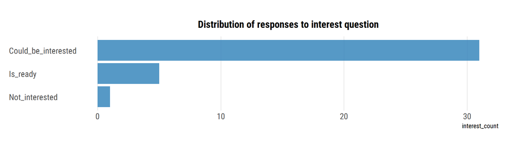

```r
survey_df_e %>%
  count(interest) %>%
  rename(interest_count = n) %>%
  mutate(interest = reorder(interest, interest_count)) %>%
  ggplot(aes(x = interest, y = interest_count)) +
  geom_col(fill = "#2C7FB8", alpha = 0.8) +
  theme_ipsum_rc(grid = "X") +
  scale_fill_ipsum() +
  coord_flip() +
  labs(title = "Distribution of responses to interest question", x = "") +
  theme(plot.title = element_text(size = 14, hjust = 0.5)) +
  theme(axis.text.y = element_text(hjust = 0)) +
  theme(plot.margin = unit(c(1,1,1,0), "cm"))
```

```r
options(scipen = 999, digits = 2)

survey_df_e %>%
  count(interest) %>%
  mutate(total = sum(n),
         percent = n / total) %>%
  select(interest, n, percent) %>%
  arrange(desc(n)) %>%
  kable() %>%
  kable_styling(bootstrap_options = c("striped","hover"),
                full_width = F, position = "left", font_size = 14)
```

| interest | n | percent |
| --- | --- | --- |
| Could_be_interested | 31 | 0.84 |
| Is_ready | 5 | 0.14 |
| Not_interested | 1 | 0.03 |

The independent variables (the appeal of a more participative platform for H1 and the opinion on projects that are co-created by social entrepreneurs and the local government through civic crowdfunding platforms for H2) are what we think could be drivers for the dependent variable (although we could not make causal inference from an observational study like this one). If the correlations are verified, then we could provide BrusselsTogether with actionnable recommendations, such as making the platform more participative or playing a role of intermediary between citizens initiatives and the local authorities.

For each of the two independent variables, we asked a set of questions which, in our opinion, should reflect their corresponding independent variable. In this case, we could say that the independent variables are latent variables that are each measured by a set of several items.

The table below displays the items and their related variable name in the R code. The items related to the appeal of a more participative platform are `p1` to `p5` and the items related to opinion on projects that are co-created by social entrepreneurs and the local government through civic crowdfunding platforms are `g1` to `g6`.

Additionnaly, we asked the respondants whether their interest in contributing to the future of their neighborhood had increased in the past several years (variable name `neighb`).

All of those items were measured on a 5-points Likert scale, from “strongly disagree” to “strongly agree”.

```r
meta <- data_frame(question = header_lookup$google_f_header[c(5:15, 29)],
                   variable_name = names(survey_df_e)[c(5:16)])

meta %>%
  kable() %>%
  kable_styling(bootstrap_options = c("striped","hover"),
                full_width = T, font_size = 14)
```

| question | variable_name |
| --- | --- |
| Face-to-face interactions are necessary for collective action. | p1 |
| For most citizens on a civic crowdfunding platform, personnally funding a citizen’s initiative is enough to satisfy their desire to engage in this project. | p2 |
| Citizens would like to participate in debates on local public issues that they care about. | p3 |
| It is relatively easy for citizens to find places where local public issues are collectively debated. | p4 |
| I would welcome the possibility for citizens on a crowdfunding platform to express their disagreement about some aspects of the projects they contribute to financially. | p5 |
| Civic crowdfunding represents a direct threat to the funding of public goods and services by the local government. | g1 |
| I regard crowdfunded citizen’s initiatives as a sort of *Do-It-Yourself government*. | g2 |
| The local government is able to identify the projects that are most wanted by citizens. | g3 |
| Civic crowdfunding platforms could play a role of intermediary between citizen’s initiatives and the local government. | g4 |
| General interest issues are addressed more efficiently by crowdfunded citizen’s initiatives than by the local government. | g5 |
| General interest issues are addressed more efficiently by crowdfunded citizen’s initiatives than by non-profit organizations subsidized by the local government. | g6 |
| My interest in contributing to the future of my neighborhood has increased in the past several years. | neighb |

The answers are distributed as shown in the three plots below:

```r
lik_plot <- function(t, my_df_names, mylevels, factor_levels, p_title) {
  tab <- rownames_to_column(data.frame(unclass(t)), "rownames_col")
  names(tab) <- my_df_names
  tab$interest <- factor(tab$interest, ordered = T, levels = factor_levels)

  numlevels <- length(tab[1,]) - 1
  numcenter <- ceiling(numlevels / 2) + 1
  tab$midvalues <- tab[,numcenter] / 2
  tab2 <- cbind(tab[,1],
                tab[,2:ceiling(numlevels / 2)],
                tab$midvalues,
                tab$midvalues,
                tab[,numcenter:numlevels + 1])

  colnames(tab2) <- c("outcome",
                      mylevels[1:floor(numlevels / 2)],
                      "midlow",
                      "midhigh",
                      mylevels[numcenter:numlevels])

  numlevels <- length(mylevels) + 1
  point1 <- 2
  point2 <- ((numlevels) / 2) + 1
  point3 <- point2 + 1
  point4 <- numlevels + 1
  mymin <- (ceiling(max(rowSums(tab2[,point1:point2])) * 4) / 4) * -100
  mymax <- (ceiling(max(rowSums(tab2[,point3:point4])) * 4) / 4) * 100

  numlevels <- length(tab[1,]) - 1
  temp.rows <- length(tab2[,1])
  pal <- brewer.pal((numlevels - 1),"BrBG")
  pal[ceiling(numlevels / 2)] <- "#DFDFDF"
  legend.pal <- pal
  pal <- c(pal[1:(ceiling(numlevels / 2) - 1)],
           pal[ceiling(numlevels / 2)],
           pal[ceiling(numlevels / 2)],
           pal[(ceiling(numlevels / 2) + 1):(numlevels - 1)])

  tab3 <- melt(tab2, id = "outcome")
  tab3$col <- rep(pal, each = temp.rows)
  tab3$value <- tab3$value * 100
  tab3$outcome <- str_wrap(tab3$outcome, width = 70)
  tab3$outcome <- factor(tab3$outcome, ordered = T,
                         levels = str_wrap(factor_levels, width = 70))
  highs <- na.omit(tab3[(length(tab3[,1]) / 2) + 1:length(tab3[,1]),])
  lows <- na.omit(tab3[1:(length(tab3[,1]) / 2),])
  lows <- lows[rev(rownames(lows)),]

  highs$col <- factor(highs$col, ordered = T, levels = c("#018571",
                                                         "#80CDC1",
                                                         "#DFDFDF"))
  lows$col <- factor(lows$col, ordered = T, levels = c("#A6611A",
                                                       "#DFC27D",
                                                       "#DFDFDF"))

  highs$outcome <- factor(highs$outcome, ordered = T,
                          levels = rev(levels(highs$outcome)))
  lows$outcome <- factor(lows$outcome, ordered = T,
                         levels = rev(levels(lows$outcome)))
  # lows$outcome
  # highs$outcome <- factor(highs$outcome, ordered = T,
  #                        levels = tab2$outcome[order(-(tab2[,5] + tab2[,6] + tab2[,7]))])

  ggplot() +
    geom_bar(data = highs, alpha = 0.8, aes(x = outcome, y = value, fill = col), position = "stack", stat = "identity") +
    geom_bar(data = lows, alpha = 0.8, aes(x = outcome, y = -value, fill = col), position = "stack", stat = "identity") +
    geom_hline(yintercept = 0, color = c("white")) +
    scale_fill_identity("Percent", labels = mylevels, breaks = legend.pal, guide = "legend") +
    theme_fivethirtyeight() +
    coord_flip() +
    theme_ipsum_rc() +
    labs(title = p_title, y = "",x = "") +
    theme(plot.title = element_text(size = 14, hjust = 0.5)) +
    theme(axis.text.y = element_text(hjust = 0)) +
    theme(legend.position = "bottom") +
    scale_y_continuous(breaks = seq(-100,100,25), limits = c(-100,100), labels = function(x) paste0(x, "%")) +
    theme(plot.margin = unit(c(1,1,1,0), "cm")) +
    theme(
      # panel.grid.major.x = element_blank(),
      # panel.grid.minor.x = element_blank(),
      panel.grid.major.y = element_blank(),
      panel.grid.minor.y = element_blank()
      )
}
```

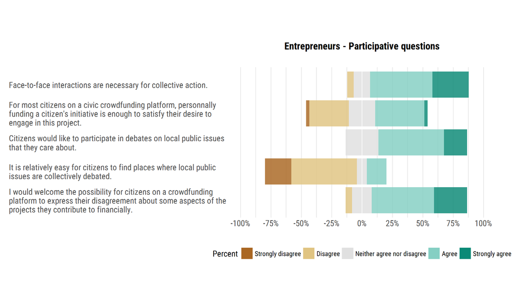

```r
questions_e <- header_lookup$google_f_header[5:15]
quest_code_e <- names(survey_df_e)[5:15]
survey_df_e_df <- as.data.frame(survey_df_e)
names(survey_df_e_df)[5:15] <- questions_e



my_df_names_e_p <- c("interest", "Strongly disagree", "Disagree", "Neither agree nor disagree",
                     "Agree", "Strongly agree")
mylevels_e_p <- c("Strongly disagree", "Disagree", "Neither agree nor disagree",
                  "Agree", "Strongly agree")
factor_levels_e_p <- c("Face-to-face interactions are necessary for collective action.",
                       "For most citizens on a civic crowdfunding platform, personnally funding a citizen's initiative is enough to satisfy their desire to engage in this project.",
                       "Citizens would like to participate in debates on local public issues that they care about.",
                       "It is relatively easy for citizens to find places where local public issues are collectively debated.",
                       "I would welcome the possibility for citizens on a crowdfunding platform to express their disagreement about some aspects of the projects they contribute to financially.")

temp_e_p <- survey_df_e_df[,5:9]

temp_e_p_gathered <- temp_e_p %>%
  gather(key = "question", value = "answer")

temp_e_p_gathered$answer <- factor(temp_e_p_gathered$answer, ordered = T,
                                   levels = mylevels_e_p)

t_e_p <- prop.table(table(temp_e_p_gathered$question,
                          temp_e_p_gathered$answer), 1)
e_p_title <- "\n\nEntrepreneurs - Participative questions\n"

lik_plot(t_e_p, my_df_names_e_p, mylevels_e_p, factor_levels_e_p, e_p_title)
```

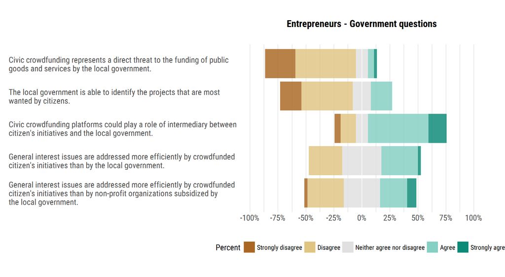

```r
my_df_names_e_g <- c("interest", "Strongly disagree", "Disagree", "Neither agree nor disagree",
                 "Agree", "Strongly agree")
mylevels_e_g <- c("Strongly disagree", "Disagree", "Neither agree nor disagree",
              "Agree", "Strongly agree")
factor_levels_e_g <- c("Civic crowdfunding represents a direct threat to the funding of public goods and services by the local government.",
                       "I regard crowdfunded citizen's initiatives as a sort of_Do-It-Yourself government_.",
                       "The local government is able to identify the projects that are most wanted by citizens.",
                       "Civic crowdfunding platforms could play a role of intermediary between citizen's initiatives and the local government.",
                       "General interest issues are addressed more efficiently by crowdfunded citizen's initiatives than by the local government.",
                       "General interest issues are addressed more efficiently by crowdfunded citizen's initiatives than by non-profit organizations subsidized by the local government.")

temp_e_g <- survey_df_e_df[,10:15]

temp_e_g_gathered <- temp_e_g %>%
  gather(key = "question", value = "answer")

temp_e_g_gathered$answer <- factor(temp_e_g_gathered$answer, ordered = T,
                                   levels = mylevels_e_g)

t_e_g <- prop.table(table(temp_e_g_gathered$question,
                          temp_e_g_gathered$answer), 1)
e_g_title <- "Entrepreneurs - Government questions\n"

lik_plot(t_e_g, my_df_names_e_g, mylevels_e_g, factor_levels_e_g, e_g_title)
```

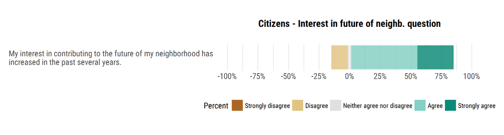

```r
questions_neighb <- header_lookup$google_f_header[29]
quest_code_neighb <- names(survey_df_e)[16]
names(survey_df_e_df)[16] <- questions_neighb

my_df_names_e_neighb <- c("interest", "Strongly disagree", "Disagree", "Neither agree nor disagree",
                          "Agree", "Strongly agree")
mylevels_e_neighb <- c("Strongly disagree", "Disagree", "Neither agree nor disagree",
                       "Agree", "Strongly agree")
factor_levels_e_neighb <- c("My interest in contributing to the future of my neighborhood has increased in the past several years.")

temp_e_neighb <- as.data.frame(survey_df_e_df[,16])
names(temp_e_neighb) <- "My interest in contributing to the future of my neighborhood has increased in the past several years."

temp_e_neighb_gathered <- temp_e_neighb %>%
  gather(key = "question", value = "answer")

temp_e_neighb_gathered$answer <- factor(temp_e_neighb_gathered$answer,
                                        ordered = T,
                                        levels = mylevels_e_neighb)

t_e_neighb <- prop.table(table(temp_e_neighb_gathered$question,
                          temp_e_neighb_gathered$answer), 1)
e_neighb_title <- "Citizens - Interest in future of neighb. question\n"

lik_plot(t_e_neighb, my_df_names_e_neighb, mylevels_e_neighb, factor_levels_e_neighb, e_neighb_title)
```

### Distribution of answers for independent variables broken down by interest

We can break down the distribution of answers related to the independent variables by interest in joining a civic crowdfunding platform.